# tseLCA Workflow

```r
library(tseLCA)
```

## Overview

`tseLCA` implements the BCH and ML bias-adjusted three-step estimators for latent class analysis (LCA) with covariates and distal outcomes, following the methodological framework for both BCH and Vermunt’s ML approaches from Bakk, Tekle & Vermunt (2013). `tseLCA` also builds on top of the two-step LCA estimation procedure outlined by Bakk & Kuha (2018), and using the R package `multilevLCA` for efficient measurement model estimation from Lyrvall et al. (2025). `tseLCA` provides analytic sandwich variance estimation that propagates measurement uncertainty through the classification-error correction in the final step.

The three-step approach separates the model into:

1. **Step 1** — Estimate the LCA measurement model (class-conditional item probabilities and class prevalences).
2. **Step 2** — Assign posterior class probabilities and compute the misclassification matrix.
3. **Step 3** — Estimate the structural model (covariate effects or distal outcome means) using the bias-adjusted weights.

## Synthetic data

The built-in data-generating process replicates the design of Bakk & Kuha (2018). Each dataset has six binary indicators ($Y_1, \ldots, Y_6$) drawn from a three-class LCA, plus either a covariate $Z_p \sim \text{Uniform}\{1,\ldots,5\}$ predicting class membership, or a continuous distal outcome $Z_o$ predicted by class membership.

```r
# High separation: P(Y_h = 1 | class) = 0.9 / 0.1
d <- generate_data(
  n = 500,
  separation = "high",
  scenario = "covariate",
  seed = 1
)
head(d)
```

```
#>   Y1 Y2 Y3 Y4 Y5 Y6 X Zp
#> 1  1  1  1  0  0  0 2  1
#> 2  0  0  0  0  0  0 3  4
#> 3  1  1  1  1  1  1 1  1
#> 4  1  1  1  1  1  0 2  2
#> 5  0  0  0  0  0  0 3  5
#> 6  1  1  1  1  1  1 1  3
```

```r
# Low separation: P(Y_h = 1 | class) = 0.7 / 0.3
# Zp and X are identical to 'd' because seed = 1
d.low <- generate_data(
  n = 500,
  separation = "low",
  scenario = "covariate",
  seed = 1
)
head(d.low)
```

```
#>   Y1 Y2 Y3 Y4 Y5 Y6 X Zp
#> 1  1  0  0  0  0  0 2  1
#> 2  0  0  0  1  1  0 3  4
#> 3  1  1  1  1  1  1 1  1
#> 4  1  1  1  1  1  1 2  2
#> 5  0  0  0  0  0  0 3  5
#> 6  1  1  1  0  1  1 1  3
```

## Step 1: Measurement model

`three_step()` with no `Zp.names` or `Zo.name` fits the measurement model only, returning a `tseLCA_measurement` object. Internally this calls `multilevLCA::multiLCA()` with random restarts when entropy $R^2$ is low.

```r
d.measurement <- three_step(
  data = d,
  Y.names = paste0("Y", 1:6),
  n_classes = 3,
  measurement.tol = 1e-8
)
summary(d.measurement)
```

```
#> -- tseLCA Measurement Model --------------------------------
#> Latent classes : 3
#> Log-likelihood : -1467.9716
#> AIC            : 2975.9433
#> BIC            : 3060.2354
#> Entropy R²     : 0.8745
#>
#> Class prevalences:
#>
#> P(C1) 0.3468
#> P(C2) 0.2950
#> P(C3) 0.3582
#> attr(,"names")
#> [1] "C1" "C2" "C3"
#>
#> Item-response probabilities (P(Y=1|class)):
#>             C1     C2     C3
#> P(Y1|C) 0.8920 0.8682 0.1187
#> P(Y2|C) 0.9340 0.8954 0.1283
#> P(Y3|C) 0.8893 0.8915 0.1077
#> P(Y4|C) 0.8473 0.0680 0.1007
#> P(Y5|C) 0.9131 0.0773 0.0908
#> P(Y6|C) 0.9018 0.0882 0.1040
```

With low separation the measurement model can struggle to find the global maximum. Use `iter.measurement` to trigger the number of random restarts whenever entropy $R^2$ falls below `R2.threshold`.

```r
d.low.measurement <- three_step(
  data = d.low,
  Y.names = paste0("Y", 1:6),
  n_classes = 3,
  iter.measurement = 10,
  R2.threshold = 0.9
)
summary(d.low.measurement)
```

```
#> -- tseLCA Measurement Model --------------------------------
#> Latent classes : 3
#> Log-likelihood : -2006.5242
#> AIC            : 4053.0483
#> BIC            : 4137.3405
#> Entropy R²     : 0.4447
#>
#> Class prevalences:
#>
#> P(C1) 0.4551
#> P(C2) 0.1723
#> P(C3) 0.3726
#> attr(,"names")
#> [1] "C1" "C2" "C3"
#>
#> Item-response probabilities (P(Y=1|class)):
#>             C1     C2     C3
#> P(Y1|C) 0.6411 0.7435 0.3010
#> P(Y2|C) 0.8222 0.7303 0.2255
#> P(Y3|C) 0.6894 0.4495 0.3511
#> P(Y4|C) 0.6122 0.2426 0.2674
#> P(Y5|C) 0.6651 0.0661 0.3165
#> P(Y6|C) 0.6540 0.1105 0.3632
```

The `plot()` S3 method delegates to `multilevLCA`’s item-profile plot.

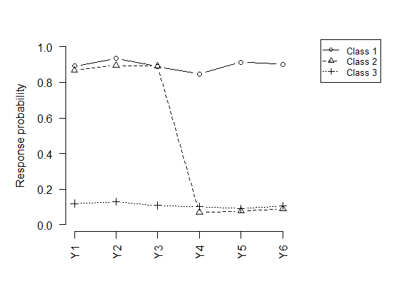

```r
plot(d.measurement)
```

## Two-step estimates

`fitZ_from_fit0()` fixes the measurement parameters at their Step-1 values and estimates multinomial logit coefficients $\gamma$ via EM. These two-step estimates serve as starting values for Step 3 and are generally close to the final three-step estimates.

```r
d.fitZ <- fitZ_from_fit0(
  fit0 = d.measurement$measurement_model$fit0,
  data = d,
  Y.names = paste0("Y", 1:6),
  Zp.names = "Zp"
)
# True slopes: -1 (C2) and +1 (C3) relative to C1
d.fitZ$mGamma
```

```
#>                   C2        C3
#> Intercept  1.7790263 -4.170998
#> Zp        -0.8401332  1.148593
```

Starting values from the high-separation fit can be passed to the low-separation fit to help it converge.

```r
d.low.fitZ <- fitZ_from_fit0(
  fit0 = d.low.measurement$measurement_model$fit0,
  data = d.low,
  Y.names = paste0("Y", 1:6),
  Zp.names = "Zp",
  starting_val = d.fitZ$mGamma
)
d.low.fitZ$mGamma
```

```
#>                   C2         C3
#> Intercept  0.1647682 -3.3962285
#> Zp        -0.5668132  0.9379231
```

## Three-step estimation

### ML estimator (default)

A single `three_step()` call handles all three steps. By default it uses the ML correction of Vermunt (2010) and modal class assignment.

```r
d.three_step <- three_step(
  data = d,
  Y.names = paste0("Y", 1:6),
  n_classes = 3,
  Zp.names = "Zp"
)
summary(d.three_step)
```

```
#> -- tseLCA Three-Step Covariate Model -----------------------
#> Latent classes : 3
#> Estimator      : ML
#> Log-likelihood : -1338.2884
#> AIC            : 2756.5768
#> BIC            : 2925.1611
#>
#> Two-step (starting) estimates:
#>                C2      C3
#> Intercept  1.7790 -4.1710
#> Zp        -0.8401  1.1486
#>
#> Three-step estimates:
#>              Estimate Std.Error z.value     p.value
#> Intercept:C2   1.8739    0.3332  5.6241 < 0.001 ***
#> Zp:C2         -0.8833    0.1434 -6.1584 < 0.001 ***
#> Intercept:C3  -4.3703    0.7495 -5.8307 < 0.001 ***
#> Zp:C3          1.1945    0.1873  6.3765 < 0.001 ***
#> ---
#> Signif. codes: 0 '***' 0.001 '**' 0.01 '*' 0.05 '.' 0.1 ' ' 1
```

The standard `coef()` and `vcov()` S3 methods work on any `tseLCA` object.

```r
coef(d.three_step)
```

```
#>                   C2        C3
#> Intercept  1.8738903 -4.370297
#> Zp        -0.8833431  1.194500
```

```r
vcov(d.three_step)
```

```
#>              Intercept:C2        Zp:C2 Intercept:C3        Zp:C3
#> Intercept:C2   0.11101469 -0.043563945  -0.04886145  0.010454710
#> Zp:C2         -0.04356395  0.020574538   0.02495107 -0.005099341
#> Intercept:C3  -0.04886145  0.024951074   0.56179310 -0.138009954
#> Zp:C3          0.01045471 -0.005099341  -0.13800995  0.035091517
```

### Proportional assignment

With modal assignment (`use.modal.assignment = TRUE`, the default), the Jacobian in the measurement-uncertainty correction is not mathematically defined. Setting `use.modal.assignment = FALSE` uses soft posterior weights throughout, giving an analytic Jacobian and is recommended when separation is moderate or low. When `use.modal.assignment = TRUE`, the Jacobian $\frac{\partial\theta_2}{\partial\theta_1}$ computed using the full posterior weights (e.g., behaving as if `use.modal.assignment = FALSE`) to maintain well-defined derivatives, though three-step estimates would still be computed with modal assignment as specified. The different is negligible when separation is high.

```r
d.three_step.prop <- three_step(
  data = d,
  Y.names = paste0("Y", 1:6),
  n_classes = 3,
  Zp.names = "Zp",
  use.modal.assignment = FALSE
)
summary(d.three_step.prop)
```

```
#> -- tseLCA Three-Step Covariate Model -----------------------
#> Latent classes : 3
#> Estimator      : ML
#> Log-likelihood : -1338.3943
#> AIC            : 2756.7886
#> BIC            : 2925.3730
#>
#> Two-step (starting) estimates:
#>                C2      C3
#> Intercept  1.7790 -4.1710
#> Zp        -0.8401  1.1486
#>
#> Three-step estimates:
#>              Estimate Std.Error z.value     p.value
#> Intercept:C2   1.8671    0.3655  5.1087 < 0.001 ***
#> Zp:C2         -0.8756    0.1581 -5.5374 < 0.001 ***
#> Intercept:C3  -4.5000    0.8015 -5.6142 < 0.001 ***
#> Zp:C3          1.2258    0.2006  6.1098 < 0.001 ***
#> ---
#> Signif. codes: 0 '***' 0.001 '**' 0.01 '*' 0.05 '.' 0.1 ' ' 1
```

### Simple (robust) standard errors

Setting `use.simple.cov = TRUE` skips the measurement-uncertainty correction and returns the robust sandwich SEs from Step 3 only. When separation is high the correction is negligible, so this is a useful computational shortcut for large samples.

```r
d.three_step.simple <- three_step(
  data = d,
  Y.names = paste0("Y", 1:6),
  n_classes = 3,
  Zp.names = "Zp",
  use.simple.cov = TRUE
)
summary(d.three_step.simple)
```

```
#> -- tseLCA Three-Step Covariate Model -----------------------
#> Latent classes : 3
#> Estimator      : ML
#> Log-likelihood : -1338.2884
#> AIC            : 2756.5768
#> BIC            : 2925.1611
#>
#> Two-step (starting) estimates:
#>                C2      C3
#> Intercept  1.7790 -4.1710
#> Zp        -0.8401  1.1486
#>
#> Three-step estimates:
#>              Estimate Std.Error z.value     p.value
#> Intercept:C2   1.8739    0.3145  5.9578 < 0.001 ***
#> Zp:C2         -0.8833    0.1323 -6.6760 < 0.001 ***
#> Intercept:C3  -4.3703    0.6863 -6.3681 < 0.001 ***
#> Zp:C3          1.1945    0.1722  6.9378 < 0.001 ***
#> ---
#> Signif. codes: 0 '***' 0.001 '**' 0.01 '*' 0.05 '.' 0.1 ' ' 1
```

### BCH estimator

The BCH correction of Bolck, Croon & Hagenaars (2004) is available via `use.bch = TRUE`. It works well with high separation but can produce an ill-conditioned Hessian when separation is low (resulting in a covariance matrix that is not positive semi-definite), in which case the ML estimator is preferred.

```r
d.three_step.bch <- three_step(
  data = d,
  Y.names = paste0("Y", 1:6),
  n_classes = 3,
  Zp.names = "Zp",
  use.bch = TRUE
)
summary(d.three_step.bch)
```

```
#> -- tseLCA Three-Step Covariate Model -----------------------
#> Latent classes : 3
#> Estimator      : BCH
#> Log-likelihood : -1338.4071
#> AIC            : 2756.8142
#> BIC            : 2925.3985
#>
#> Two-step (starting) estimates:
#>                C2      C3
#> Intercept  1.7790 -4.1710
#> Zp        -0.8401  1.1486
#>
#> Three-step estimates:
#>              Estimate Std.Error z.value     p.value
#> Intercept:C2   1.9274    0.3346  5.7596 < 0.001 ***
#> Zp:C2         -0.9084    0.1468 -6.1880 < 0.001 ***
#> Intercept:C3  -3.9789    0.6458 -6.1609 < 0.001 ***
#> Zp:C3          1.1066    0.1636  6.7662 < 0.001 ***
#> ---
#> Signif. codes: 0 '***' 0.001 '**' 0.01 '*' 0.05 '.' 0.1 ' ' 1
```

BCH with low-separation data can fail to produce a positive semi-definite Hessian. The ML estimator with proportional assignment is more reliable in this setting.

```r
# Not run in vignette build (slow and and produces warnings)
bch.fail <- three_step(
  data = d.low,
  Y.names = paste0("Y", 1:6),
  n_classes = 3,
  Zp.names = "Zp",
  use.bch = TRUE,
  maxIter.measurement = 2000,
  iter.measurement = 10
)
```

```r
# Preferred approach for low separation
d.low.three_step.prop <- three_step(
  data = d.low,
  Y.names = paste0("Y", 1:6),
  n_classes = 3,
  Zp.names = "Zp",
  use.modal.assignment = FALSE
)
summary(d.low.three_step.prop)
```

```
#> -- tseLCA Three-Step Covariate Model -----------------------
#> Latent classes : 3
#> Estimator      : ML
#> Log-likelihood : -1974.5489
#> AIC            : 4029.0977
#> BIC            : 4197.6821
#>
#> Two-step (starting) estimates:
#>                C2      C3
#> Intercept  0.1594 -3.3877
#> Zp        -0.5637  0.9358
#>
#> Three-step estimates:
#>              Estimate Std.Error z.value     p.value
#> Intercept:C2   0.9140    2.5972  0.3519 0.7249
#> Zp:C2         -1.0336    2.8770 -0.3593 0.7194
#> Intercept:C3  -4.2276    2.7433 -1.5411 0.1233
#> Zp:C3          1.1703    0.6606  1.7717 0.0764  .
#> ---
#> Signif. codes: 0 '***' 0.001 '**' 0.01 '*' 0.05 '.' 0.1 ' ' 1
```

## Choosing the reference class

By default, class 1 (`"C1"`) is the reference category for the multinomial logit parameterisation. The `rebase` argument changes this. Estimates are reparameterised consistently: log-likelihoods are invariant, and the coefficients satisfy the transitivity relation $\log(\pi_t / \pi_j) = \log(\pi_t / \pi_1) - \log(\pi_j / \pi_1)$.

```r
# Default: C1 as reference
summary(d.three_step.simple)
```

```
#> -- tseLCA Three-Step Covariate Model -----------------------
#> Latent classes : 3
#> Estimator      : ML
#> Log-likelihood : -1338.2884
#> AIC            : 2756.5768
#> BIC            : 2925.1611
#>
#> Two-step (starting) estimates:
#>                C2      C3
#> Intercept  1.7790 -4.1710
#> Zp        -0.8401  1.1486
#>
#> Three-step estimates:
#>              Estimate Std.Error z.value     p.value
#> Intercept:C2   1.8739    0.3145  5.9578 < 0.001 ***
#> Zp:C2         -0.8833    0.1323 -6.6760 < 0.001 ***
#> Intercept:C3  -4.3703    0.6863 -6.3681 < 0.001 ***
#> Zp:C3          1.1945    0.1722  6.9378 < 0.001 ***
#> ---
#> Signif. codes: 0 '***' 0.001 '**' 0.01 '*' 0.05 '.' 0.1 ' ' 1
```

```r
d.three_step.simpleC2 <- three_step(
  data = d,
  Y.names = paste0("Y", 1:6),
  n_classes = 3,
  Zp.names = "Zp",
  use.simple.cov = TRUE,
  rebase = "C2"
)
summary(d.three_step.simpleC2)
```

```
#> -- tseLCA Three-Step Covariate Model -----------------------
#> Latent classes : 3
#> Estimator      : ML
#> Log-likelihood : -1338.2884
#> AIC            : 2756.5768
#> BIC            : 2925.1611
#>
#> Two-step (starting) estimates:
#>                C1      C3
#> Intercept -1.7786 -5.9494
#> Zp         0.8400  1.9884
#>
#> Three-step estimates:
#>              Estimate Std.Error z.value     p.value
#> Intercept:C1  -1.8739    0.3145 -5.9578 < 0.001 ***
#> Zp:C1          0.8833    0.1323  6.6760 < 0.001 ***
#> Intercept:C3  -6.2442    0.7785 -8.0213 < 0.001 ***
#> Zp:C3          2.0778    0.2245  9.2571 < 0.001 ***
#> ---
#> Signif. codes: 0 '***' 0.001 '**' 0.01 '*' 0.05 '.' 0.1 ' ' 1
```

```r
d.three_step.simpleC3 <- three_step(
  data = d,
  Y.names = paste0("Y", 1:6),
  n_classes = 3,
  Zp.names = "Zp",
  use.simple.cov = TRUE,
  rebase = "C3"
)
summary(d.three_step.simpleC3)
```

```
#> -- tseLCA Three-Step Covariate Model -----------------------
#> Latent classes : 3
#> Estimator      : ML
#> Log-likelihood : -1338.2884
#> AIC            : 2756.5768
#> BIC            : 2925.1611
#>
#> Two-step (starting) estimates:
#>                C1      C2
#> Intercept  4.1707  5.9494
#> Zp        -1.1484 -1.9884
#>
#> Three-step estimates:
#>              Estimate Std.Error z.value     p.value
#> Intercept:C1   4.3703    0.6863  6.3681 < 0.001 ***
#> Zp:C1         -1.1945    0.1722 -6.9378 < 0.001 ***
#> Intercept:C2   6.2442    0.7785  8.0213 < 0.001 ***
#> Zp:C2         -2.0778    0.2245 -9.2571 < 0.001 ***
#> ---
#> Signif. codes: 0 '***' 0.001 '**' 0.01 '*' 0.05 '.' 0.1 ' ' 1
```

## Passing a pre-fitted measurement model

The `step1` argument accepts any previously fitted `tseLCA` object or the raw output of `lca_step1()`. This is useful when you want to:

- Reuse an expensive measurement model across multiple structural models.
- Estimate the measurement model on a large reference sample and apply it to a smaller analysis sample.
- Inject custom two-step starting values computed via `fitZ_from_fit0()`.

```r
# Reuse the measurement model estimated above
d.three_step.prop2 <- three_step(
  data = d,
  Y.names = paste0("Y", 1:6),
  n_classes = 3,
  Zp.names = "Zp",
  use.modal.assignment = FALSE,
  step1 = d.measurement$measurement_model
)
summary(d.three_step.prop2)
```

```
#> -- tseLCA Three-Step Covariate Model -----------------------
#> Latent classes : 3
#> Estimator      : ML
#> Log-likelihood : -1338.3943
#> AIC            : 2756.7886
#> BIC            : 2925.3730
#>
#> Two-step (starting) estimates:
#>                C2      C3
#> Intercept  1.7790 -4.1710
#> Zp        -0.8401  1.1486
#>
#> Three-step estimates:
#>              Estimate Std.Error z.value     p.value
#> Intercept:C2   1.8671    0.3655  5.1087 < 0.001 ***
#> Zp:C2         -0.8756    0.1581 -5.5374 < 0.001 ***
#> Intercept:C3  -4.5000    0.8015 -5.6142 < 0.001 ***
#> Zp:C3          1.2258    0.2006  6.1098 < 0.001 ***
#> ---
#> Signif. codes: 0 '***' 0.001 '**' 0.01 '*' 0.05 '.' 0.1 ' ' 1
```

```r
# Measurement model from a larger low-separation sample
d.low2000 <- generate_data(
  n = 2000,
  separation = "low",
  scenario = "covariate",
  seed = 2
)
d.low.measurement2000 <- three_step(
  data = d.low2000,
  Y.names = paste0("Y", 1:6),
  n_classes = 3
)

# Apply to the smaller sample; get.twostep.vcov returns multilevLCA's
# bias-corrected vcov for the two-step estimates
d.low.three_step.prop2 <- three_step(
  data = d.low,
  Y.names = paste0("Y", 1:6),
  n_classes = 3,
  Zp.names = "Zp",
  use.modal.assignment = FALSE,
  step1 = d.low.measurement2000$measurement_model,
  get.twostep.vcov = TRUE
)
summary(d.low.three_step.prop2)
```

```
#> -- tseLCA Three-Step Covariate Model -----------------------
#> Latent classes : 3
#> Estimator      : ML
#> Log-likelihood : -1986.2163
#> AIC            : 4052.4326
#> BIC            : 4221.0169
#>
#> Two-step (starting) estimates:
#>                C2      C3
#> Intercept  1.3695 -4.0518
#> Zp        -0.3249  1.0992
#>
#> Three-step estimates:
#>              Estimate Std.Error z.value     p.value
#> Intercept:C2   1.3459    0.6945  1.9379 0.0526  .
#> Zp:C2         -0.2675    0.2217 -1.2068 0.2275
#> Intercept:C3  -4.9811    1.1875 -4.1946 < 0.001 ***
#> Zp:C3          1.2693    0.2475  5.1276 < 0.001 ***
#> ---
#> Signif. codes: 0 '***' 0.001 '**' 0.01 '*' 0.05 '.' 0.1 ' ' 1
```

You can also compute two-step starting values separately and inject them before calling `three_step()`.

```r
d.low.fitZ2 <- fitZ_from_fit0(
  fit0 = d.low.measurement2000$measurement_model$fit0,
  data = d.low,
  Y.names = paste0("Y", 1:6),
  Zp.names = "Zp"
)
d.low.measurement2000$measurement_model$fitZ <- d.low.fitZ2

d.low.three_step.prop3 <- three_step(
  data = d.low,
  Y.names = paste0("Y", 1:6),
  n_classes = 3,
  Zp.names = "Zp",
  use.modal.assignment = FALSE,
  step1 = d.low.measurement2000$measurement_model
)
summary(d.low.three_step.prop3)
```

```
#> -- tseLCA Three-Step Covariate Model -----------------------
#> Latent classes : 3
#> Estimator      : ML
#> Log-likelihood : -1986.2163
#> AIC            : 4052.4326
#> BIC            : 4221.0169
#>
#> Two-step (starting) estimates:
#>                C2      C3
#> Intercept  1.3695 -4.0518
#> Zp        -0.3249  1.0992
#>
#> Three-step estimates:
#>              Estimate Std.Error z.value     p.value
#> Intercept:C2   1.3459    0.6945  1.9379 0.0526  .
#> Zp:C2         -0.2675    0.2217 -1.2068 0.2275
#> Intercept:C3  -4.9811    1.1875 -4.1946 < 0.001 ***
#> Zp:C3          1.2693    0.2475  5.1276 < 0.001 ***
#> ---
#> Signif. codes: 0 '***' 0.001 '**' 0.01 '*' 0.05 '.' 0.1 ' ' 1
```

## Missing data

`tseLCA` uses a two-pass row-filtering strategy that matches `multilevLCA`’s approach for the measurement model while allowing more observations into Steps 1 and 2 than Step 3.

```r
set.seed(42)
d.new <- generate_data(500, separation = "high", seed = 3)
sparsity <- 0.1
missing <- 1 -
  matrix(
    rbinom(prod(dim(d.new)), size = 1, prob = sparsity),
    nrow = nrow(d.new),
    ncol = ncol(d.new)
  )
missing[missing == 0] <- NA_real_
d.sparse <- d.new * missing
head(d.sparse)
```

```
#>   Y1 Y2 Y3 Y4 Y5 Y6  X Zp
#> 1  0  0 NA  0  0  0  3  5
#> 2  1  1 NA  1  1  1  1  2
#> 3  0  0  1  0  0  1  3  4
#> 4  1  1  1  1  1  1  1  4
#> 5  0  1  1  1  1  1 NA  2
#> 6  1  0 NA  0  0  0  3  3
```

With `incomplete = FALSE` (the default), any row with a missing indicator is dropped before the measurement model is estimated.

```r
d.sparse.measurement <- three_step(
  data = d.sparse,
  Y.names = paste0("Y", 1:6),
  n_classes = 3,
  incomplete = FALSE,
  verbose = TRUE
)
```

```
#> 242 row(s) dropped from measurement/classification steps (missing Y).
```

```r
# Rows dropped = number of rows with at least one missing Y
sum(apply(d.sparse[, paste0("Y", 1:6)], 1, \(x) any(is.na(x))))
```

```
#> [1] 242
```

```r
summary(d.sparse.measurement)
```

```
#> -- tseLCA Measurement Model --------------------------------
#> Latent classes : 3
#> Log-likelihood : -763.0984
#> AIC            : 1566.1968
#> BIC            : 1637.2559
#> Entropy R²     : 0.8835
#>
#> Class prevalences:
#>
#> P(C1) 0.2914
#> P(C2) 0.3924
#> P(C3) 0.3162
#> attr(,"names")
#> [1] "C1" "C2" "C3"
#>
#> Item-response probabilities (P(Y=1|class)):
#>             C1     C2     C3
#> P(Y1|C) 0.9038 0.9015 0.1078
#> P(Y2|C) 0.8920 0.9116 0.0938
#> P(Y3|C) 0.8558 0.8980 0.1073
#> P(Y4|C) 0.9546 0.0841 0.0945
#> P(Y5|C) 0.8999 0.1121 0.1224
#> P(Y6|C) 0.9116 0.1262 0.1677
```

With `incomplete = TRUE`, only fully-missing rows are dropped; partially observed rows contribute to the measurement model via FIML.

```r
d.sparse.measurement2 <- three_step(
  data = d.sparse,
  Y.names = paste0("Y", 1:6),
  n_classes = 3,
  incomplete = TRUE,
  verbose = TRUE
)
summary(d.sparse.measurement2)
```

```
#> -- tseLCA Measurement Model --------------------------------
#> Latent classes : 3
#> Log-likelihood : -1372.3013
#> AIC            : 2784.6025
#> BIC            : 2868.8947
#> Entropy R²     : 0.8376
#>
#> Class prevalences:
#>
#> P(C1) 0.3064
#> P(C2) 0.3764
#> P(C3) 0.3171
#> attr(,"names")
#> [1] "C1" "C2" "C3"
#>
#> Item-response probabilities (P(Y=1|class)):
#>             C1     C2     C3
#> P(Y1|C) 0.8697 0.8820 0.0864
#> P(Y2|C) 0.8965 0.8784 0.1405
#> P(Y3|C) 0.8527 0.8662 0.0796
#> P(Y4|C) 0.9424 0.0817 0.0902
#> P(Y5|C) 0.9159 0.1019 0.1156
#> P(Y6|C) 0.9106 0.1184 0.1592
```

Regardless of `incomplete`, Step 3 drops any row with a missing covariate. The rows used in Step 3 are a subset of those used in Steps 1 and 2.

```r
d.sparse.three_step <- three_step(
  data = d.sparse,
  Y.names = paste0("Y", 1:6),
  n_classes = 3,
  Zp.names = "Zp",
  incomplete = TRUE,
  verbose = TRUE
)
```

```
#> 43 row(s) excluded from covariate step (missing Z).
#> fitZ EM converged in 9 iterations.
#> 43 row(s) excluded from covariate step (missing Z).
#> EM converged in 6 iterations.
```

```r
# Additional rows dropped from Step 3 due to missing Zp
sum(is.na(d.sparse$Zp))
```

```
#> [1] 43
```

```r
summary(d.sparse.three_step)
```

```
#> -- tseLCA Three-Step Covariate Model -----------------------
#> Latent classes : 3
#> Estimator      : ML
#> Log-likelihood : -1126.5227
#> AIC            : 2333.0454
#> BIC            : 2498.0327
#>
#> Two-step (starting) estimates:
#>                C2      C3
#> Intercept  2.6367 -4.1123
#> Zp        -1.0765  1.0957
#>
#> Three-step estimates:
#>              Estimate Std.Error z.value     p.value
#> Intercept:C2   2.6060    0.4420  5.8966 < 0.001 ***
#> Zp:C2         -1.0627    0.1946 -5.4619 < 0.001 ***
#> Intercept:C3  -4.2255    0.5825 -7.2547 < 0.001 ***
#> Zp:C3          1.1247    0.1499  7.5016 < 0.001 ***
#> ---
#> Signif. codes: 0 '***' 0.001 '**' 0.01 '*' 0.05 '.' 0.1 ' ' 1
```

A FIML measurement model can be passed in and then reused for the covariate step on the same sparse data.

```r
d.sparse.three_step2 <- three_step(
  data = d.sparse,
  Y.names = paste0("Y", 1:6),
  n_classes = 3,
  Zp.names = "Zp",
  incomplete = TRUE,
  step1 = d.sparse.measurement2$measurement_model,
  verbose = TRUE
)
```

```
#> 43 row(s) excluded from covariate step (missing Z).
#> fitZ EM converged in 9 iterations.
#> 43 row(s) excluded from covariate step (missing Z).
#> EM converged in 6 iterations.
```

```r
summary(d.sparse.three_step2)
```

```
#> -- tseLCA Three-Step Covariate Model -----------------------
#> Latent classes : 3
#> Estimator      : ML
#> Log-likelihood : -1126.5227
#> AIC            : 2333.0454
#> BIC            : 2498.0327
#>
#> Two-step (starting) estimates:
#>                C2      C3
#> Intercept  2.6367 -4.1123
#> Zp        -1.0765  1.0957
#>
#> Three-step estimates:
#>              Estimate Std.Error z.value     p.value
#> Intercept:C2   2.6060    0.4420  5.8966 < 0.001 ***
#> Zp:C2         -1.0627    0.1946 -5.4619 < 0.001 ***
#> Intercept:C3  -4.2255    0.5825 -7.2547 < 0.001 ***
#> Zp:C3          1.1247    0.1499  7.5016 < 0.001 ***
#> ---
#> Signif. codes: 0 '***' 0.001 '**' 0.01 '*' 0.05 '.' 0.1 ' ' 1
```